# Final BF

Sanket

2024-12-09

## Correctly import the data.

```r
library(fpp)
library(fpp2)
```

```r
library(TTR)
library(ggplot2)
library(readr)
library(dplyr)
library(forecast)
library(tidyverse)
data <- read.csv("C:/Users/Sanket Khamkar/Downloads/TOTALSA.csv")
names(data)
```

```
## [1] "Date"                     "Sales.Units.in.Millions."
```

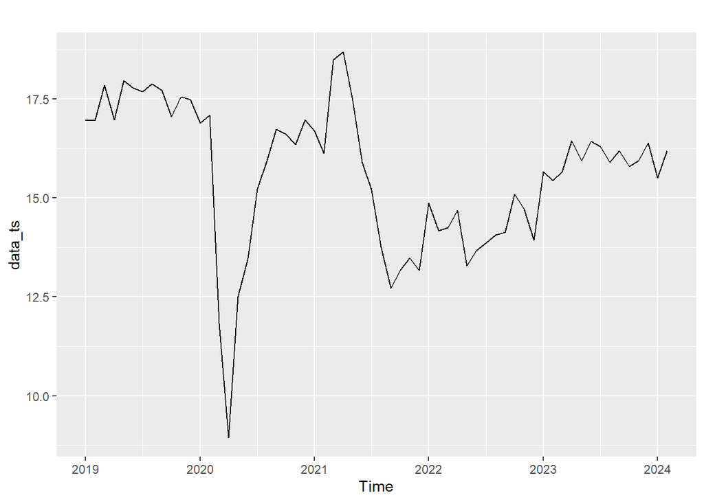

```r
data_ts <- ts(data$Sales, start = c(2019,1) , end = c(2024,2), frequency = 12)
autoplot(data_ts)
```

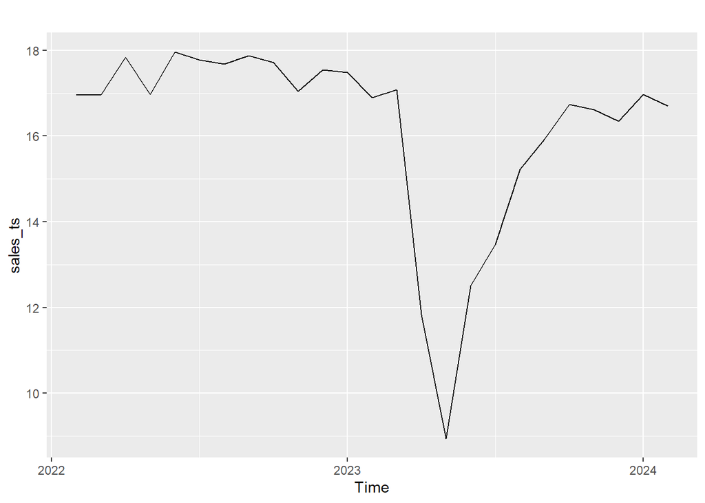

```r
sales_ts <- ts(data$Sales, start = c(2022,2) , end = c(2024,2), frequency = 12)
autoplot(sales_ts)
```

Plot and Inference • Show a time series plot.

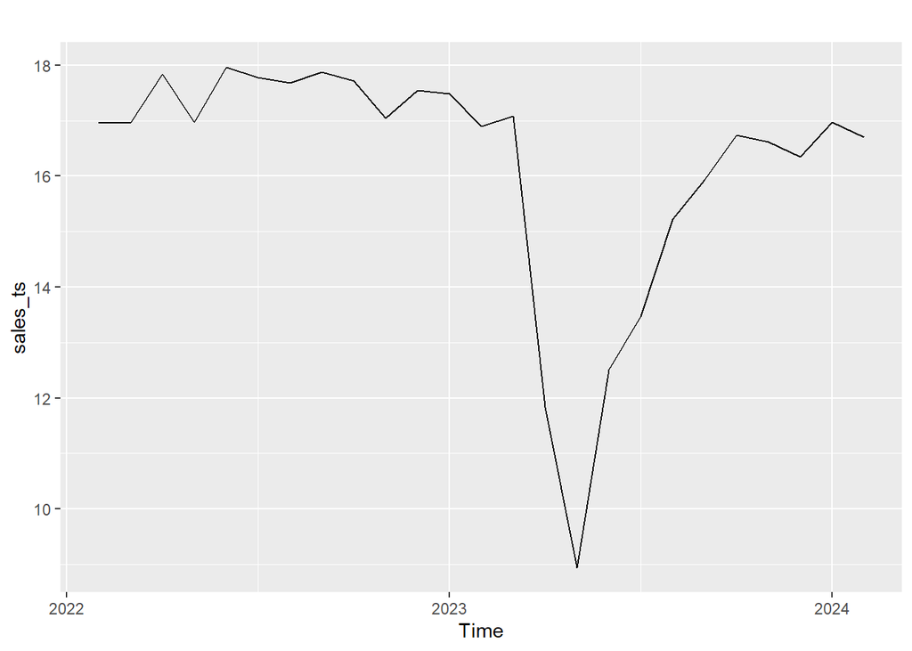

```r
autoplot(sales_ts)
```

Please summaries your observations of the times series plot

• The time series plot shows years on X-axis and sales on Y-axis

• The time series shows mostly stable values around 17-18 until mid-2023. There is a sharp drop in 2023, reaching a low point below 10. However, the series quickly rebounds and recovers toward late 2023 and 2024, showing an upward trend and stabilizing again.

##Central Tendency

• What are the min, max, mean, median, 1st, and 3rd Quartile values of the times series?

```r
summary(sales_ts)
```

```
##    Min. 1st Qu.  Median    Mean 3rd Qu.    Max.
##   8.944  16.352  16.968  16.205  17.549  17.967
```

From the summary statistics:

Minimum (Min): 8.944 1st Quartile (Q1): 16.352 Median: 16.968 Mean: 16.205 3rd Quartile (Q3): 17.549 Maximum (Max): 17.967

• Show the box plot.  
• Can you summarize your observation about the time series from the summary stats and box plot?

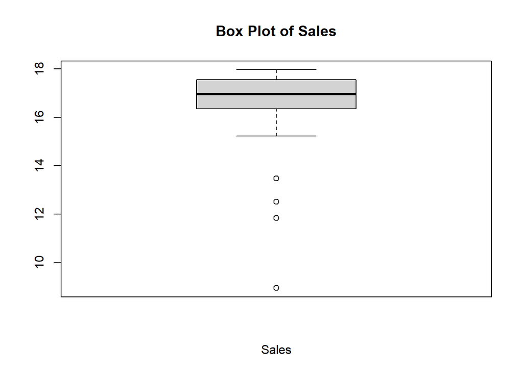

```r
boxplot(sales_ts, main="Box Plot of Sales", xlab="Sales")
```

##Decomopistion

• Plot the decomposition of the time series.

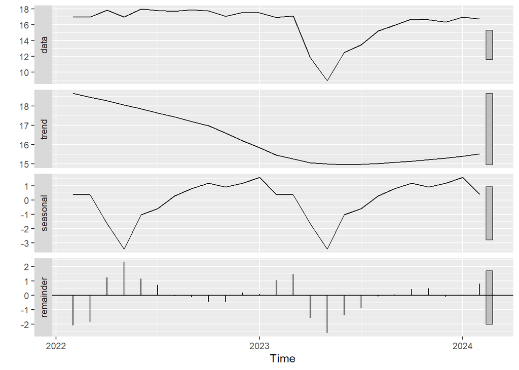

```r
sales_decomp <- stl(sales_ts,s.window ="periodic")
autoplot(sales_decomp)
```

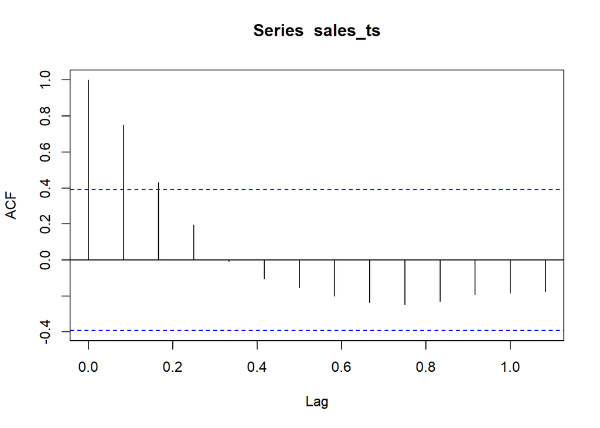

```r
acf(sales_ts)
```

• Is the time series seasonal?

Yes, the time series has seasonality, as shown in the seasonal component. There are regular fluctuations that repeat over time.

• Is the decomposition additive or multiplicative?

The decomposition appears additive because the seasonal, trend, and remainder components combine additively to reconstruct the original data.

• If seasonal, what are the values of the seasonal monthly indices?

```r
print(sales_decomp)
```

```
##  Call:
##  stl(x = sales_ts, s.window = "periodic")
##
## Components
##            seasonal    trend    remainder
## Feb 2022  0.3971576 18.65878 -2.085934699
## Mar 2022  0.3581977 18.46326 -1.859457185
## Apr 2022 -1.6447612 18.26774  1.219019370
## May 2022 -3.4259221 18.05904  2.334881502
## Jun 2022 -1.0425830 17.85034  1.159243633
## Jul 2022 -0.5954014 17.64113  0.735273827
## Aug 2022  0.2917801 17.43192 -0.041695979
## Sep 2022  0.8043048 17.20474 -0.127040636
## Oct 2022  1.1858296 16.97756 -0.443385292
## Nov 2022  0.9211951 16.58873 -0.460925702
## Dec 2022  1.1745606 16.19991  0.174533887
## Jan 2023  1.5756448 15.83103  0.084325410
## Feb 2023  0.3971576 15.46215  1.033688268
## Mar 2023  0.3581977 15.25627  1.473528480
## Apr 2023 -1.6447612 15.05039 -1.569632267
## May 2023 -3.4259221 15.00170 -2.631774481
## Jun 2023 -1.0425830 14.95300 -1.402416696
## Jul 2023 -0.5954014 14.98621 -0.920803646
## Aug 2023  0.2917801 15.01941 -0.086190596
## Sep 2023  0.8043048 15.07361  0.054082458
## Oct 2023  1.1858296 15.12781  0.425355512
## Nov 2023  0.9211951 15.21076  0.481040442
## Dec 2023  1.1745606 15.29371 -0.116274628
## Jan 2024  1.5756448 15.40160 -0.005248985
## Feb 2024  0.3971576 15.50949  0.790347995
```

The values fluctuate between +1 and -3. The seasonal pattern dips sharply around mid-year (2023) and rises again toward the beginning and end of the year.

• For which month is the time series value high, and for which month is it low?

```r
print(sales_ts)
```

```
##         Jan    Feb    Mar    Apr    May    Jun    Jul    Aug    Sep    Oct
## 2022        16.970 16.962 17.842 16.968 17.967 17.781 17.682 17.882 17.720
## 2023 17.491 16.893 17.088 11.836  8.944 12.508 13.470 15.225 15.932 16.739
## 2024 16.972 16.697
##         Nov    Dec
## 2022 17.049 17.549
## 2023 16.613 16.352
## 2024
```

High value from the time series is June 2022 with the value 17.967(in millons) and the low value from the time series is May 2023 with the value 8.944(in millons)

• Can you think of the reason behind the high and low values in those months? The high and low values may reflect seasonal demand changes.

For example: High values at the start and end of the year could relate to holiday seasons or year-end purchases. Low values in the middle of the year may be due to reduced economic activity or summer vacations.

Naïve Method • Output

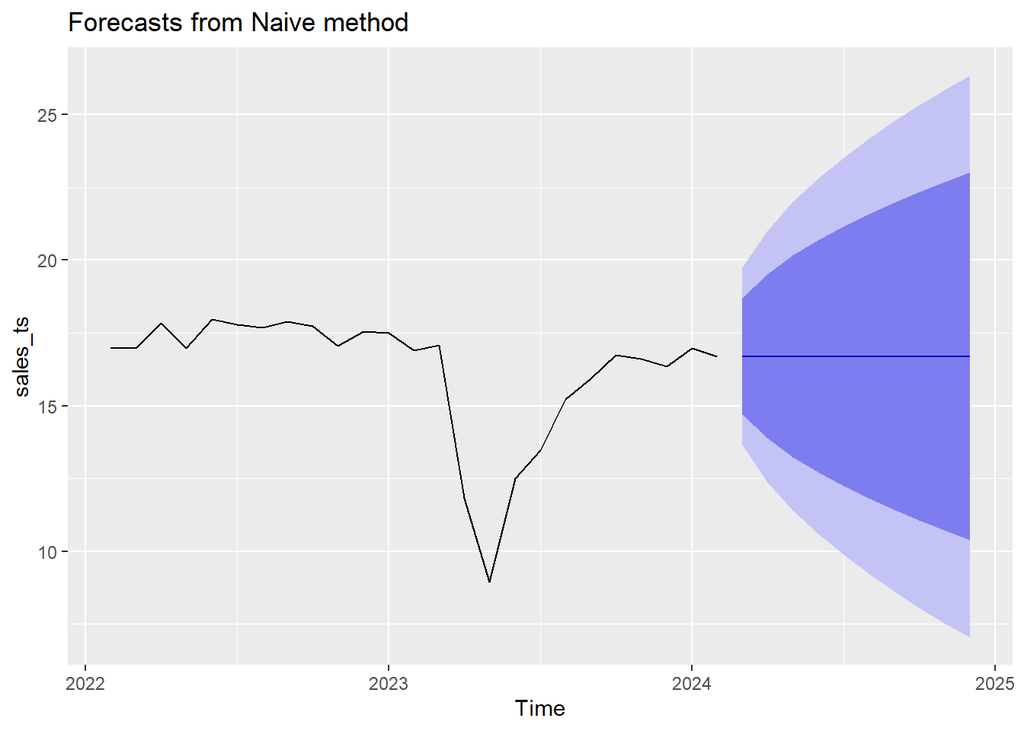

```r
naive_fc <- naive(sales_ts)
autoplot(naive_fc)
```

• Perform Residual Analysis for this technique. o Do a plot of residuals. What does the plot indicate?

This helps to check if there are patterns left, which may indicate a poor fit.

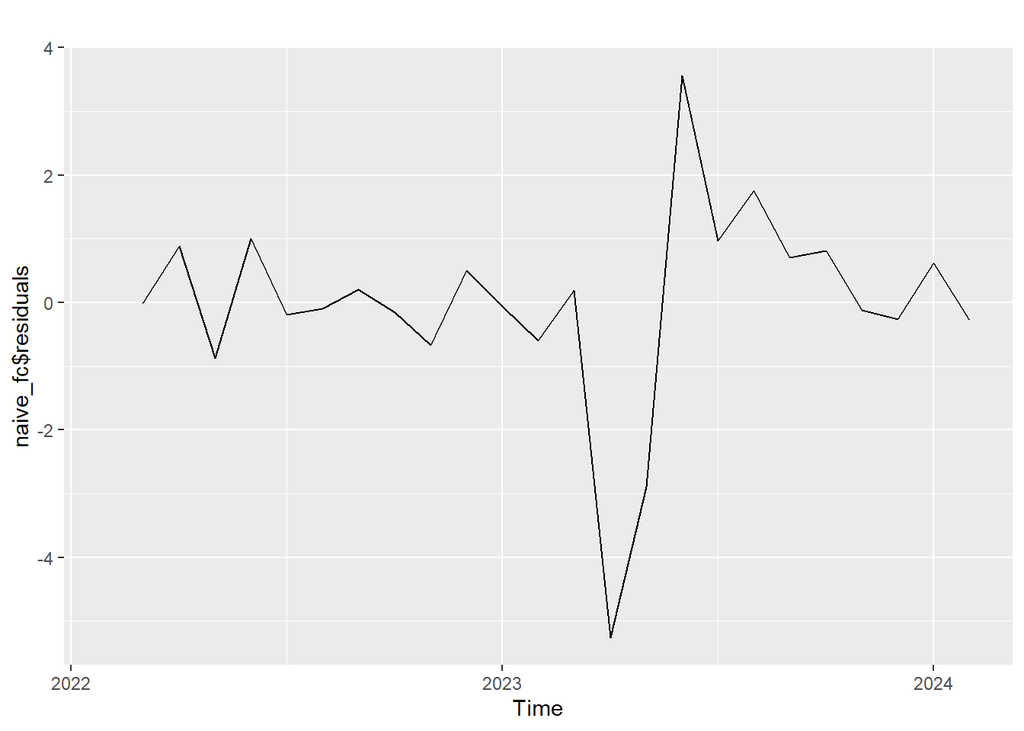

```r
autoplot(naive_fc$residuals)
```

The plot of residuals shows that the errors fluctuate around zero, but there are noticeable spikes, especially a large one in 2023. This indicates that the Naïve method struggles to capture sudden changes or unusual patterns in the data. Residuals are generally small otherwise, showing the method works reasonably well for stable periods.

o Do a Histogram plot of residuals. What does the plot indicate?

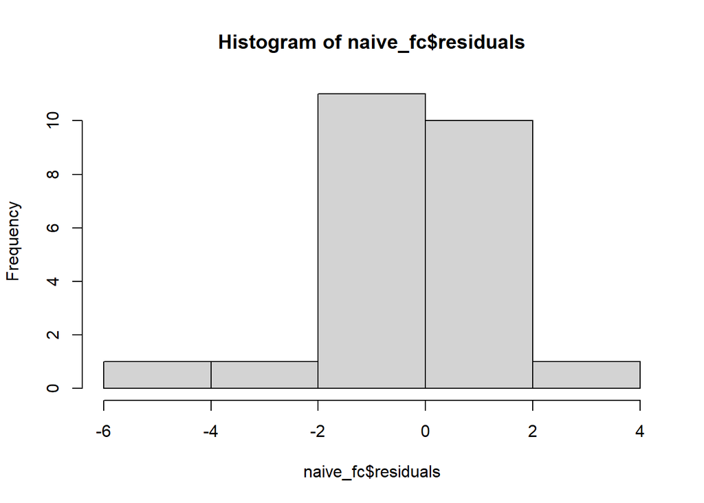

```r
hist(naive_fc$residuals)
```

The histogram of residuals shows the following: Shape: The residuals are not perfectly symmetric and appear slightly skewed to the left. Center: Most residuals are clustered around 0, indicating the model does not systematically overpredict or underpredict. Spread: The range of residuals is between approximately -6 and +3, showing that the model’s errors vary moderately but are generally small. Outliers: There are a few extreme negative values, which indicate occasional larger errors.

While the majority of residuals are close to zero, the slight skewness and outliers suggest that the Naïve method may not fully capture the underlying pattern of the data. However, the residuals are largely concentrated near zero, which is a good sign for a simple forecasting method like Naïve.

o Do a plot of fitted values vs. residuals. What does the plot indicate?

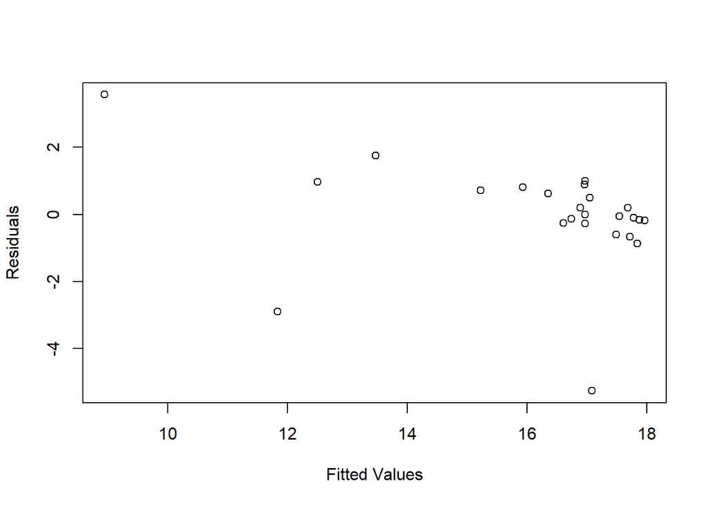

```r
plot(as.numeric(fitted(naive_fc)), residuals(naive_fc), type='p', ylab='Residuals', xlab='Fitted Values')
```

The plot of fitted values vs. residuals shows that the residuals are scattered randomly around zero, with no clear pattern. This indicates that the Naïve method does not systematically overpredict or underpredict. However, a few points with larger errors suggest the model struggles with some extreme values or sudden changes. Overall, the residuals look mostly consistent for most fitted values.

o Do a plot of actual values vs. residuals. What does the plot indicate?

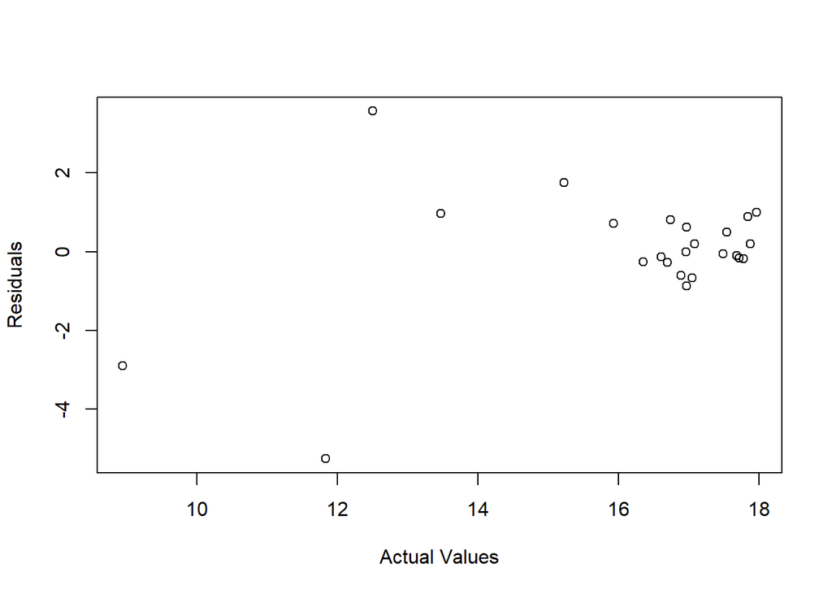

```r
plot(as.numeric(sales_ts), residuals(naive_fc), type='p', ylab='Residuals', xlab='Actual Values')
```

The plot of actual values vs. residuals shows that the residuals are mostly scattered around zero for higher actual values, but larger errors appear for lower actual values. This suggests the Naïve method performs well when actual values are stable but struggles to predict during periods with sudden drops or extreme changes.

o Do an ACF plot of the residuals? What does this plot indicate?

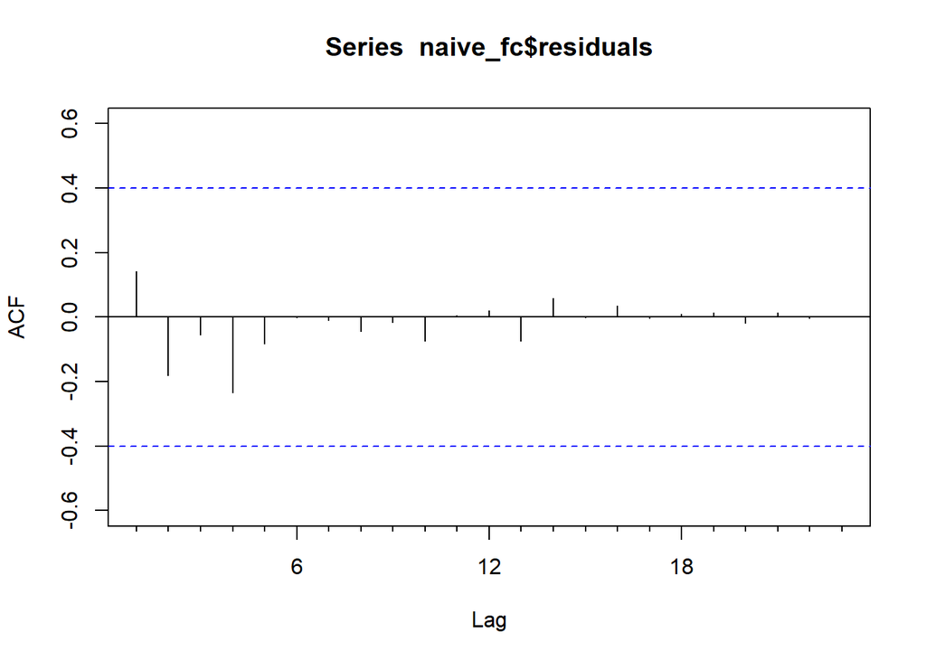

```r
Acf(naive_fc$residuals)
```

The ACF plot of the residuals shows that all autocorrelations fall within the blue confidence bounds, indicating that the residuals are mostly uncorrelated over time.

The Naïve method has effectively captured most of the patterns in the data. There are no significant autocorrelations, suggesting that the residuals behave like white noise, which is a good sign for the forecasting model. This indicates that the model’s errors do not have any remaining structure or trend.

##### • Print the 5 measures of accuracy for this forecasting technique

```r
accuracy(naive_fc)
```

```
##                     ME    RMSE       MAE        MPE     MAPE      MASE
## Training set -0.011375 1.55585 0.9437917 -0.8566293 7.162925 0.3865683
##                   ACF1
## Training set 0.1407748
```

• Forecast o Time series value for next year. Show table and plot

```r
naive_forecast1 <- forecast(naive_fc,12)
naive_forecast1
```

```
##          Point Forecast    Lo 80    Hi 80     Lo 95    Hi 95
## Mar 2024         16.697 14.70310 18.69090 13.647590 19.74641
## Apr 2024         16.697 13.87720 19.51680 12.384483 21.00952
## May 2024         16.697 13.24346 20.15054 11.415267 21.97873
## Jun 2024         16.697 12.70920 20.68480 10.598180 22.79582
## Jul 2024         16.697 12.23850 21.15550  9.878312 23.51569
## Aug 2024         16.697 11.81296 21.58104  9.227501 24.16650
## Sep 2024         16.697 11.42163 21.97237  8.629019 24.76498
## Oct 2024         16.697 11.05739 22.33661  8.071966 25.32203
## Nov 2024         16.697 10.71529 22.67871  7.548770 25.84523
## Dec 2024         16.697 10.39173 23.00227  7.053918 26.34008
```

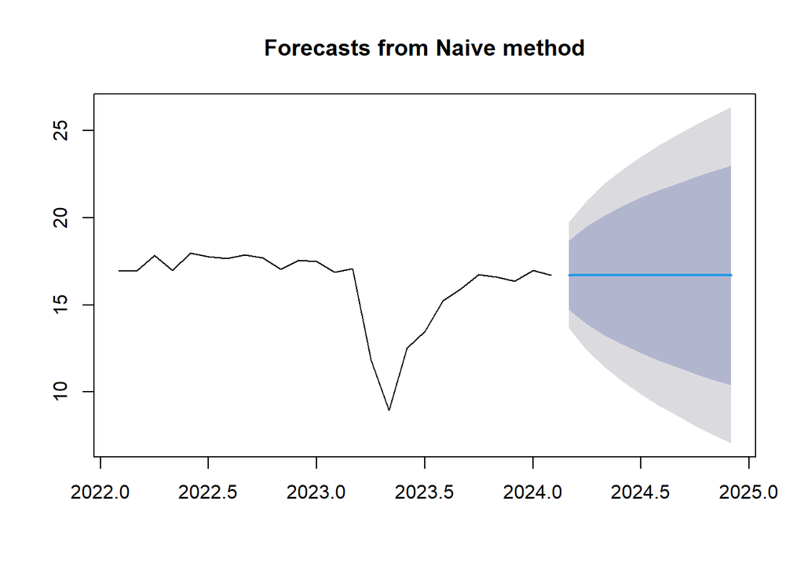

```r
plot(naive_forecast1)
```

• Summarize this forecasting technique o How good is the accuracy? The Naïve method provides a simple forecast by carrying forward the last observed value. While it works for stable time series, it may struggle with sudden drops or trends. The residual analysis indicates small errors overall but with a few larger deviations, especially during unexpected changes.

o Other observation The Naïve method does not capture trends or seasonality; it assumes stability. Confidence intervals widen significantly into the future, reflecting increased uncertainty. It’s a useful baseline method for comparison with more advanced models.

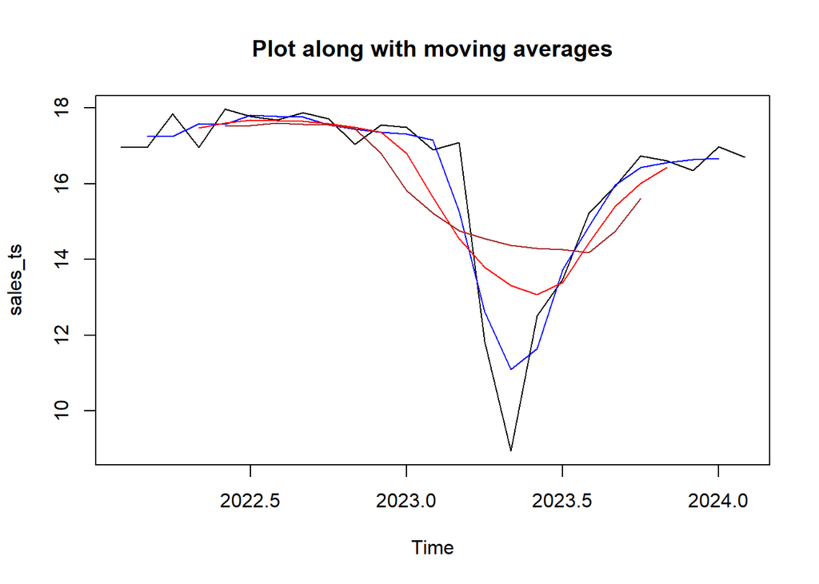

```r
mavg3_forecast = ma(sales_ts,order=3)
mavg6_forecast = ma(sales_ts,order=6)
mavg9_forecast = ma(sales_ts,order=9)
plot(sales_ts, main = "Plot along with moving averages")
lines(mavg3_forecast, col="Blue")
lines(mavg6_forecast, col="Red")
lines(mavg9_forecast, col="Brown")
```

• (Bonus) show the forecast for the next 12 months using one of the simple average orders that you feel works best for time series.

It adapts well to changes in the data while smoothing out noise, making it more reliable for short-term forecasts.

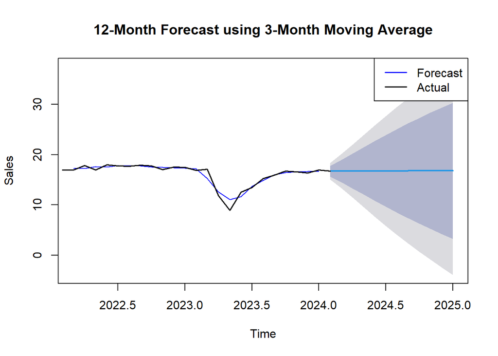

```r
# Load required library
library(forecast)

# 3-Month Moving Average
mavg3_forecast <- ma(sales_ts, order = 3)

# Remove NA values from the moving average
mavg3_clean <- na.omit(mavg3_forecast)

# Forecast the next 12 months based on the cleaned series
mavg3_extended <- forecast(mavg3_clean, h = 12)

# Plot the forecast along with the original series
plot(mavg3_extended, main = "12-Month Forecast using 3-Month Moving Average",
     xlab = "Time", ylab = "Sales", col = "blue")
lines(sales_ts, col = "black", lwd = 1.5) # Overlay actual series
legend("topright", legend = c("Forecast", "Actual"),
       col = c("blue", "black"), lty = 1, lwd = 1.5)
```

• What are your observations of the plot as the moving average order goes up? As the moving average order increases, the line becomes smoother but reacts slower to changes and closer to mean. A lower order (like 3) balances smoothing and responsiveness, while higher orders stabilize the forecast but can miss sharp drops or trends.

#### 7.Simple Smoothing

##### • Perform a simple smoothing forecast for next 12 months for the time series.

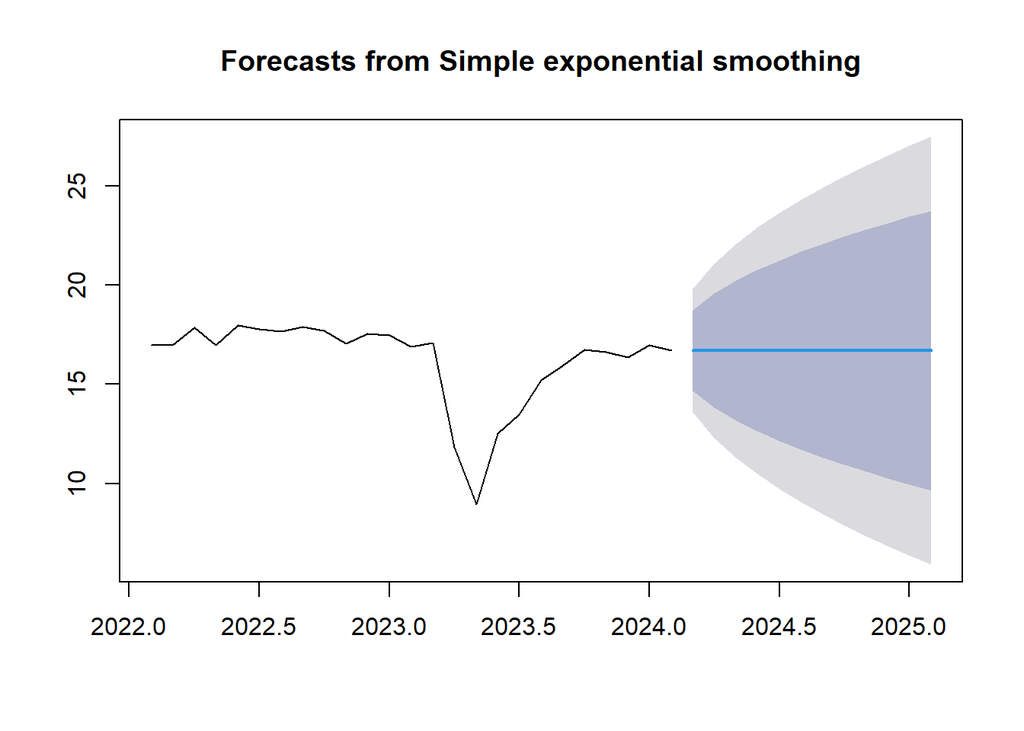

```r
ses_forecast <- ses(sales_ts,12)
plot(ses_forecast)
```

```r
summary(ses_forecast)
```

```
##
## Forecast method: Simple exponential smoothing
##
## Model Information:
## Simple exponential smoothing
##
## Call:
## ses(y = sales_ts, h = 12)
##
##   Smoothing parameters:
##     alpha = 0.9999
##
##   Initial states:
##     l = 16.9589
##
##   sigma:  1.5893
##
##      AIC     AICc      BIC
## 107.5532 108.6961 111.2098
##
## Error measures:
##                       ME     RMSE       MAE        MPE     MAPE      MASE
## Training set -0.01047621 1.524439 0.9064964 -0.8198541 6.879213 0.3712925
##                   ACF1
## Training set 0.1408489
##
## Forecasts:
##          Point Forecast     Lo 80    Hi 80     Lo 95    Hi 95
## Mar 2024       16.69703 14.660210 18.73385 13.581984 19.81207
## Apr 2024       16.69703 13.816677 19.57738 12.291911 21.10214
## May 2024       16.69703 13.169391 20.22466 11.301974 22.09208
## Jun 2024       16.69703 12.623698 20.77036 10.467408 22.92665
## Jul 2024       16.69703 12.142930 21.25113  9.732136 23.66192
## Aug 2024       16.69703 11.708280 21.68578  9.067397 24.32666
## Sep 2024       16.69703 11.308577 22.08548  8.456104 24.93795
## Oct 2024       16.69703 10.936542 22.45751  7.887125 25.50693
## Nov 2024       16.69703 10.587119 22.80694  7.352728 26.04133
## Dec 2024       16.69703 10.256625 23.13743  6.847282 26.54677
## Jan 2025       16.69703  9.942283 23.45177  6.366537 27.02752
## Feb 2025       16.69703  9.641932 23.75212  5.907190 27.48687
```

o What is the value of alpha? What does that value signify? The alpha value (0.9999) specifies the coefficient for the level smoothing. Values near 1.0 mean that the latest value has more weight.

o What is the value of the initial state? Initial State: 16.9589 – The starting value for the smoothing process.

o What is the value of sigma? What does the sigma signify? Sigma: 1.5893 – Represents the error’s standard deviation, indicating small but noticeable variability in predictions

• Perform Residual Analysis for this technique. o Do a plot of residuals. What does the plot indicate?

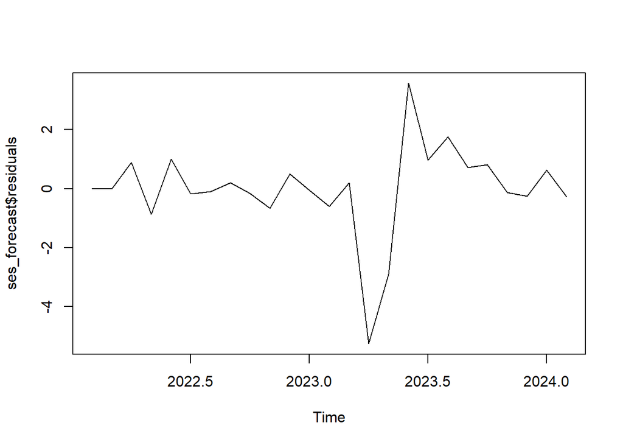

```r
plot(ses_forecast$residuals)
```

The residual plot shows that errors fluctuate around zero without a clear pattern, which is a good sign. However, there are a few noticeable spikes, indicating that the model struggles with sudden changes or large variations in the data. Overall, the residuals appear fairly random, suggesting the model fits the data reasonably well.

o Do a Histogram plot of residuals. What does the plot indicate?

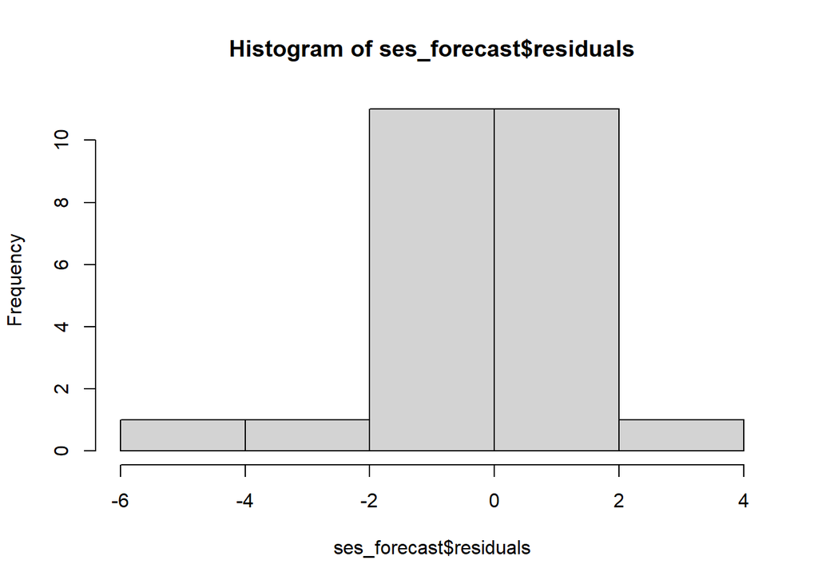

```r
hist(ses_forecast$residuals)
```

The histogram of residuals shows that most errors are centered around zero, with a slight spread on both sides. This indicates that the model’s predictions are generally accurate, but there are a few larger errors, particularly on the negative side. Overall, the distribution looks fairly balanced, suggesting the model works reasonably well for the data.

o Do a plot of fitted values vs. residuals. What does the plot indicate?

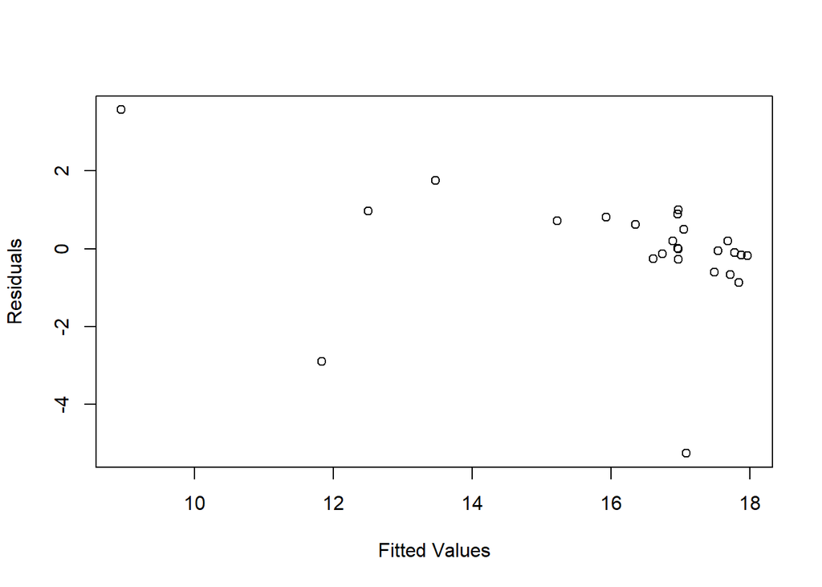

```r
plot(as.numeric(fitted(ses_forecast)), residuals(ses_forecast), type='p', ylab='Residuals', xlab='Fitted Values')
```

The plot of fitted values vs. residuals shows that residuals are scattered randomly around zero, which is a good sign. However, there are a few outliers, especially at the lower end, indicating that the model struggles with some extreme values. Overall, the randomness suggests the model captures the main pattern well without obvious bias.

o Do a plot of actual values vs. residuals. What does the plot indicate?

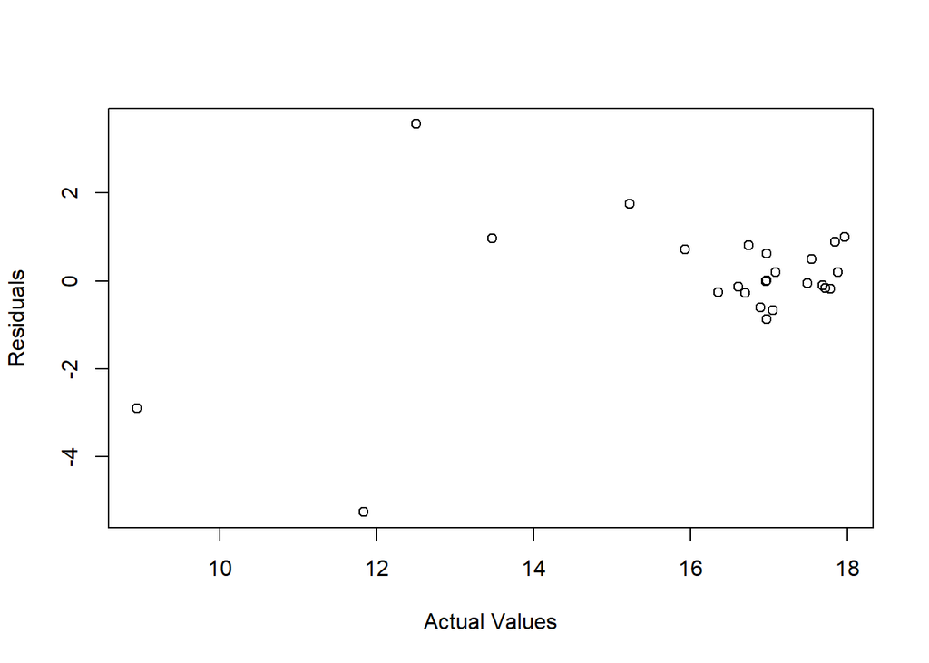

```r
plot(as.numeric(sales_ts), residuals(ses_forecast), type='p', ylab='Residuals', xlab='Actual Values')
```

The plot of actual values vs. residuals shows that most residuals are close to zero for higher actual values, indicating a good fit. However, for lower actual values, there are a few larger errors, suggesting the model struggles to predict extreme low points. Overall, the residuals are fairly random, meaning the model does not show significant bias.

o Do an ACF plot of the residuals? What does this plot indicate?

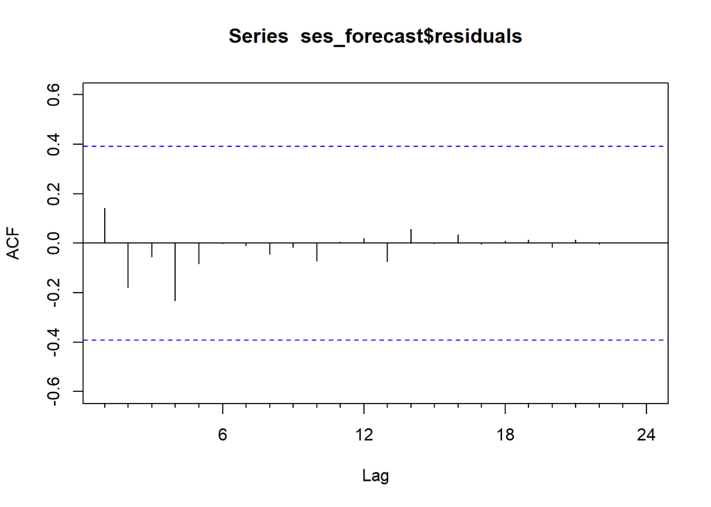

```r
Acf(ses_forecast$residuals)
```

The ACF plot of residuals shows that all autocorrelations fall within the blue confidence bands, meaning there’s no significant pattern left in the residuals. This indicates that the Simple Exponential Smoothing model has captured the main structure of the data well, and the residuals behave like random noise.

• Print the five measures of accuracy for this forecasting technique

```r
accuracy(ses_forecast)
```

```
##                       ME     RMSE       MAE        MPE     MAPE      MASE
## Training set -0.01047621 1.524439 0.9064964 -0.8198541 6.879213 0.3712925
##                   ACF1
## Training set 0.1408489
```

```r
# Perform Simple Exponential Smoothing
ses_forecast <- ses(sales_ts, h = 12)
print(ses_forecast)
```

```
##          Point Forecast     Lo 80    Hi 80     Lo 95    Hi 95
## Mar 2024       16.69703 14.660210 18.73385 13.581984 19.81207
## Apr 2024       16.69703 13.816677 19.57738 12.291911 21.10214
## May 2024       16.69703 13.169391 20.22466 11.301974 22.09208
## Jun 2024       16.69703 12.623698 20.77036 10.467408 22.92665
## Jul 2024       16.69703 12.142930 21.25113  9.732136 23.66192
## Aug 2024       16.69703 11.708280 21.68578  9.067397 24.32666
## Sep 2024       16.69703 11.308577 22.08548  8.456104 24.93795
## Oct 2024       16.69703 10.936542 22.45751  7.887125 25.50693
## Nov 2024       16.69703 10.587119 22.80694  7.352728 26.04133
## Dec 2024       16.69703 10.256625 23.13743  6.847282 26.54677
## Jan 2025       16.69703  9.942283 23.45177  6.366537 27.02752
## Feb 2025       16.69703  9.641932 23.75212  5.907190 27.48687
```

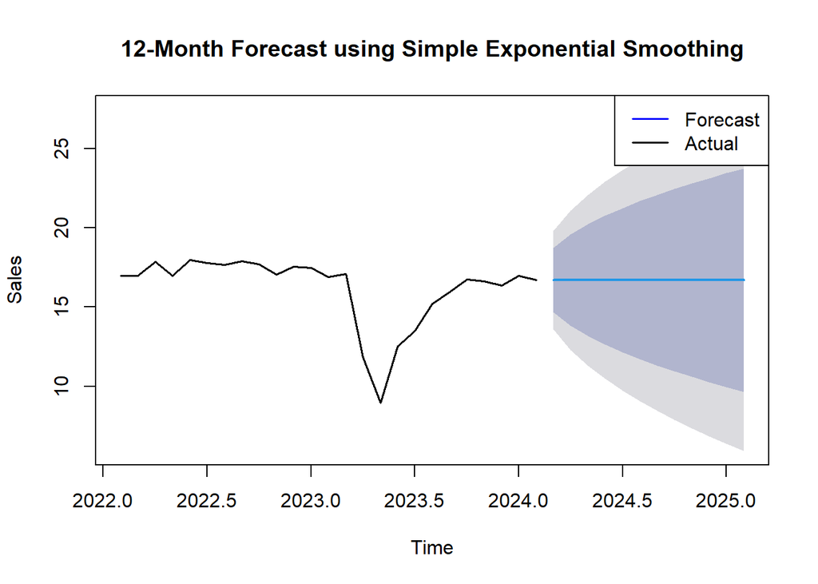

```r
# Plot the forecast
plot(ses_forecast, main = "12-Month Forecast using Simple Exponential Smoothing",
     xlab = "Time", ylab = "Sales", col = "blue")
lines(sales_ts, col = "black", lwd = 1.5) # Overlay actual time series
legend("topright", legend = c("Forecast", "Actual"),
       col = c("blue", "black"), lty = 1, lwd = 1.5)
```

• Summarize this forecasting technique o How good is the accuracy? The model works well for stable data but struggles with sudden drops, as seen in the past values. The residuals are small overall, meaning the accuracy is reasonable.

o Other observation The confidence interval widens over time, showing increasing uncertainty. The model does not handle sharp changes well because it smooths the data and assumes stability. It’s simple and effective for steady trends but may underperform for highly variable data.

###Holt-Winters • Perform Holt-Winters forecast for next 12 months for the time series.

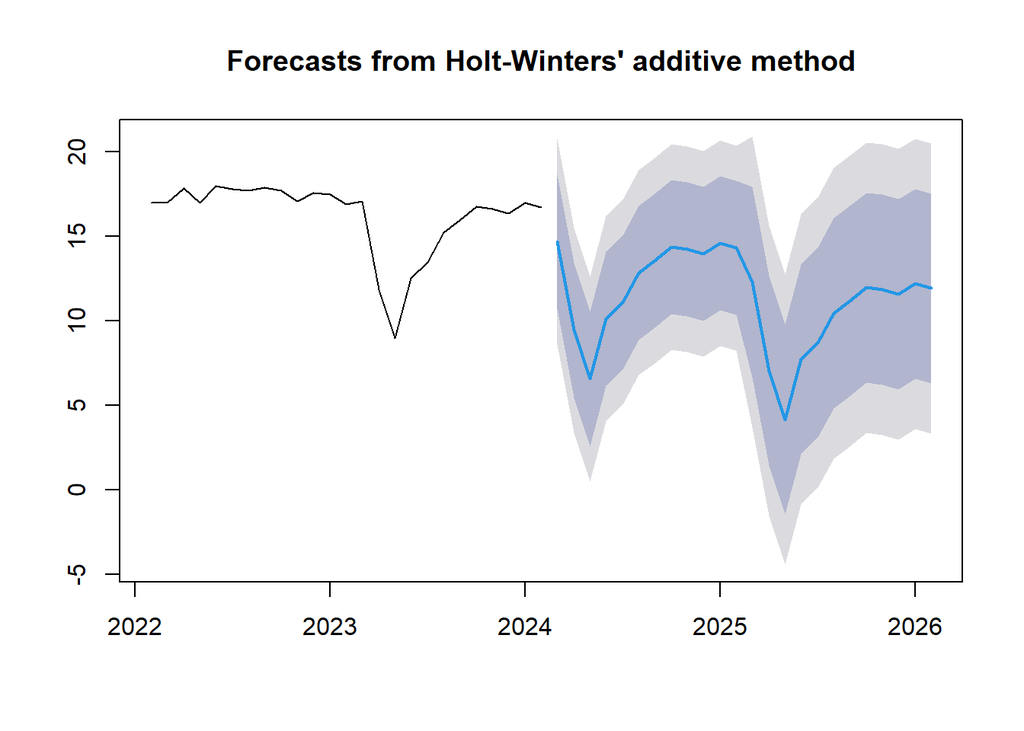

```r
HW_forecast <- hw(sales_ts, seasonal = "additive")
plot(forecast(HW_forecast))
```

```r
HW_forecast$model
```

```
## Holt-Winters' additive method
##
## Call:
## hw(y = sales_ts, seasonal = "additive")
##
##   Smoothing parameters:
##     alpha = 0.0018
##     beta  = 1e-04
##     gamma = 0.9982
##
##   Initial states:
##     l = 18.7948
##     b = -0.1993
##     s = 1.2512 0.8072 -0.188 0.9322 0.408 0.3472
##            0.3492 0.3122 -0.8815 -0.0361 -1.2853 -2.0162
##
##   sigma:  3.0971
##
##      AIC     AICc      BIC
## 145.4532 232.8818 166.1741
```

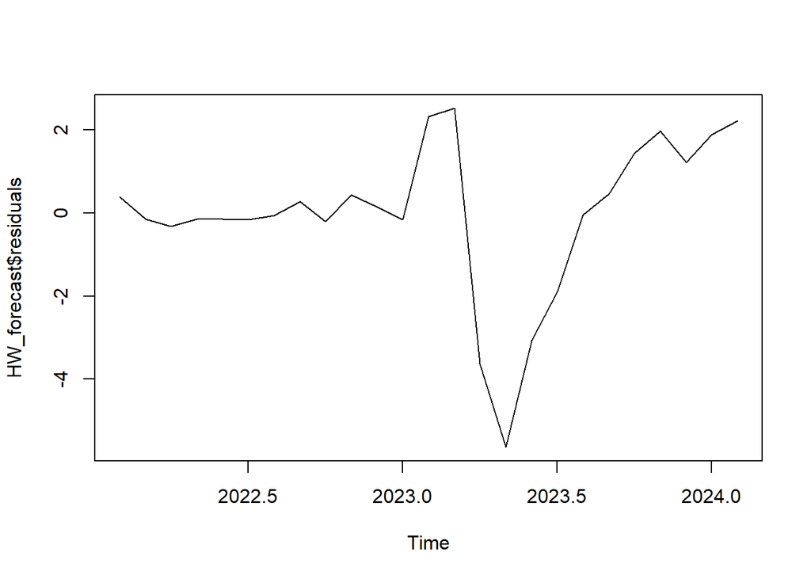

```r
plot(HW_forecast$residuals)
```

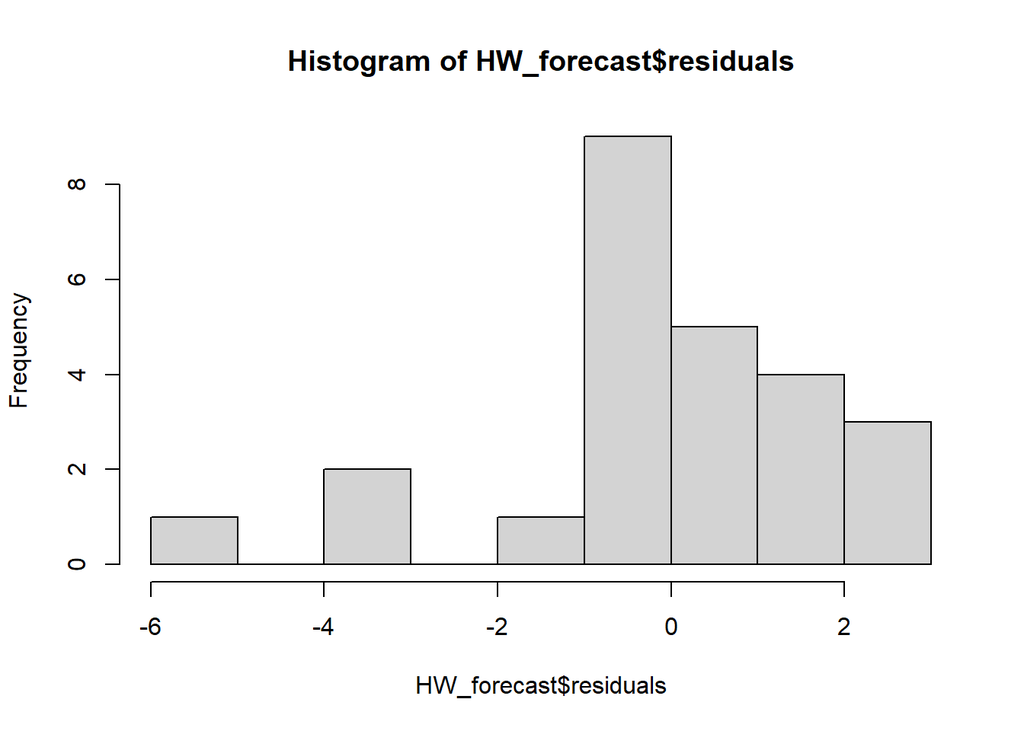

```r
hist(HW_forecast$residuals)
```

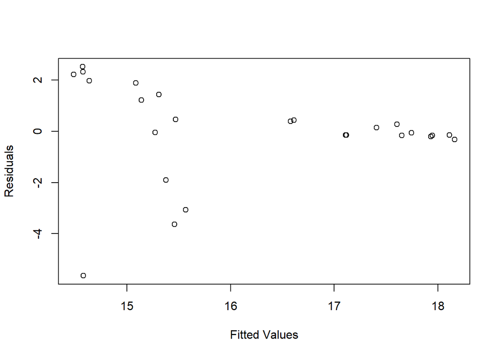

```r
plot(as.numeric(fitted(HW_forecast)), residuals(HW_forecast), type='p', ylab='Residuals', xlab='Fitted Values')
```

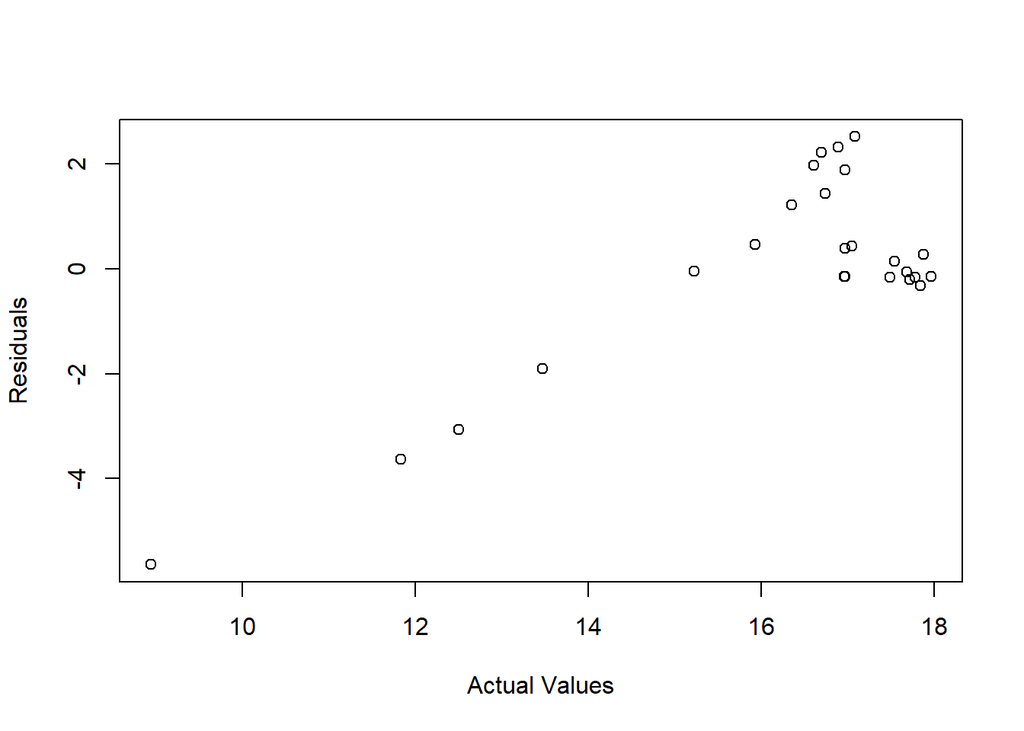

```r
plot(as.numeric(sales_ts), residuals(HW_forecast), type='p', ylab='Residuals', xlab='Actual Values')
```

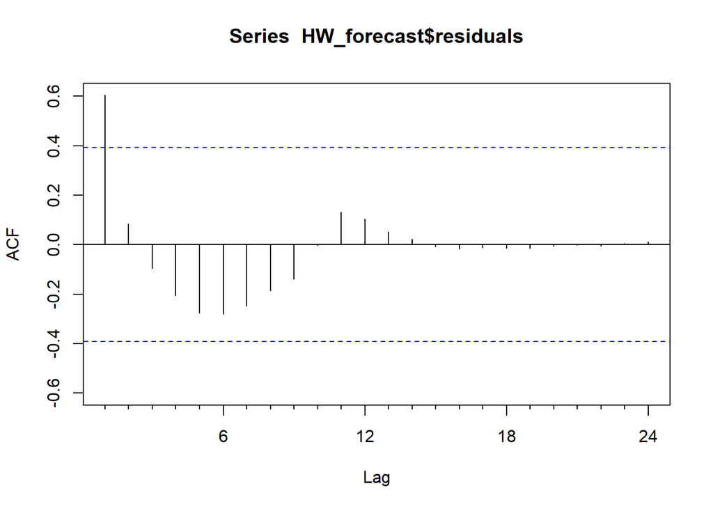

```r
Acf(HW_forecast$residuals)
```

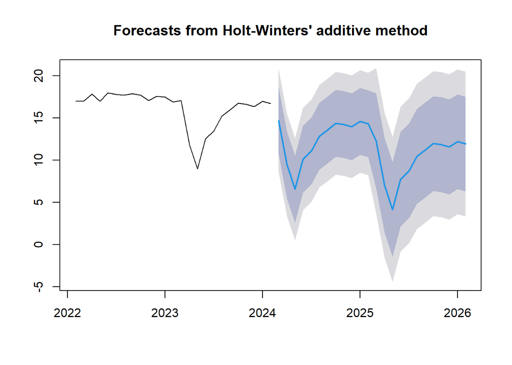

```r
HW_forecast2<-forecast(HW_forecast,12)
plot(HW_forecast2)
```

#What is the value of alpha? What does that value signify? The value of alpha is 0.0018.Alpha is the smoothing parameter for the level component. A low value of alpha indicates that the model gives more weight to past data and less weight to recent observations for estimating the level.

#What is the value of beta? What does that value signify? The value of beta is 0.0001.Beta is the smoothing parameter for the trend component. A very low beta suggests that the trend is stable over time and changes very slowly

#What is the value of gamma? What does that value signify? The value of gamma is 0.9982.Gamma is the smoothing parameter for the seasonal component. A high gamma value indicates that the seasonal component adapts quickly to changes in seasonality.

What is the value of initial states for the level, trend, and seasonality? What do these values signify? Initial state values: Level (l): 18.7948 Trend (b): -0.1993 Seasonality (s): Values in the list from 1.2512 to -2.0162.These values represent the starting points for the level, trend, and seasonal components used by the model for forecasting.

What is the value of sigma? What does the sigma signify? The value of sigma is 3.0971.Sigma represents the standard deviation of the residuals (errors). It quantifies the average deviation of observed values from the fitted model values. A smaller sigma indicates a better fit.

#Perform Residual Analysis for this technique.  
Do a plot of residuals. What does the plot indicate?

Do a Histogram plot of residuals. What does the plot indicate? The histogram shows residuals mostly centered around zero, indicating a good overall fit. However, the slight skewness suggests the model may underpredict certain values.”

#Do a plot of fitted values vs. residuals. What does the plot indicate?  
The graph shows that the model’s residuals are relatively small for higher fitted values, indicating better accuracy in those cases. However, larger residuals occur for lower fitted values, suggesting the model struggles with lower data points.

#Do an ACF plot of the residuals? What does this plot indicate? The ACF plot of residuals shows significant autocorrelation at lower lags, indicating that the model has not fully captured all patterns or dependencies in the data. This suggests room for improvement in the model to better handle underlying structures or seasonality.

• Summarize this forecasting technique o How good is the accuracy? Accuracy: Holt-Winters’ method works well for data with a seasonal pattern and slight trends. It adapts better than simple smoothing methods, capturing the recurring fluctuations.

o Other observation The model shows seasonality clearly in the forecast, which wasn’t captured by simpler methods. The confidence interval widens over time, indicating more uncertainty in long-term predictions. It handles variability better but might still struggle with sudden shifts.

```r
nsdiffs(sales_ts)
```

```
## [1] 0
```

```r
data_diff<-(diff(sales_ts,differences = 1))
```

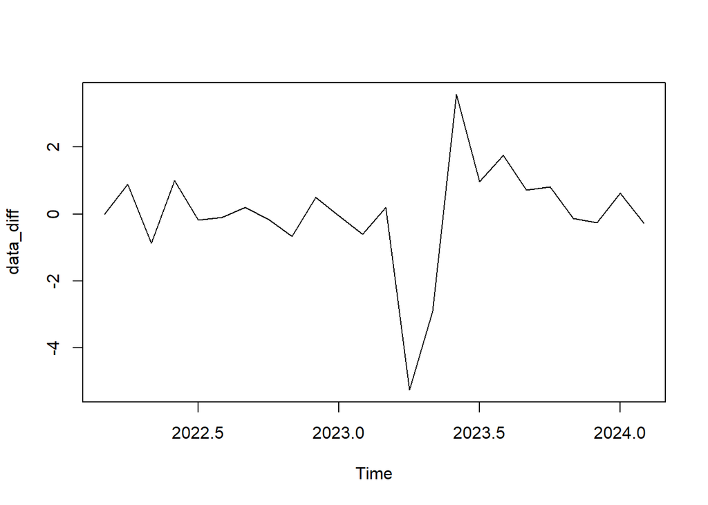

```r
plot(data_diff)
```

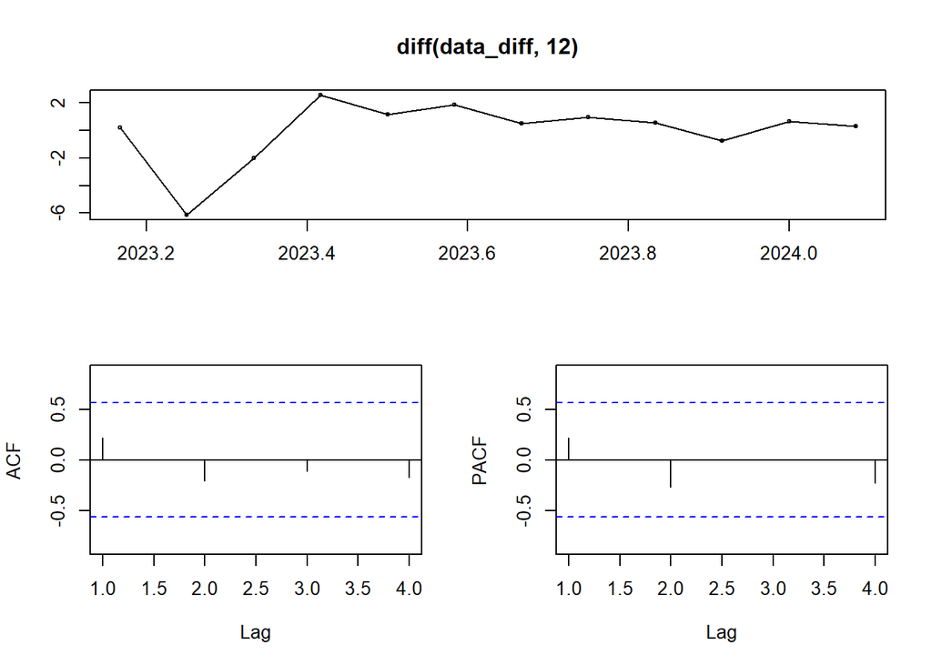

```r
tsdisplay(diff(data_diff,12))
```

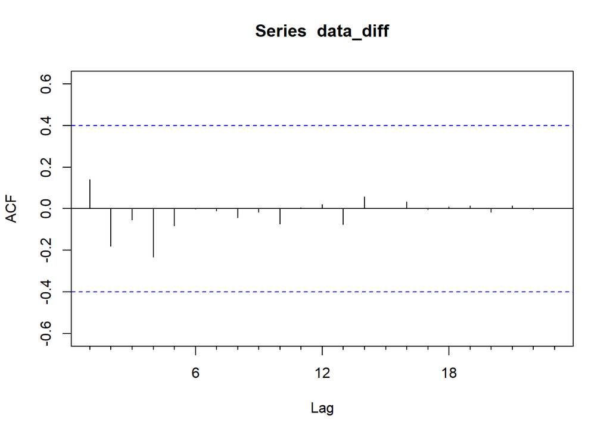

```r
#Plot the ACF and PACF plot of the differenced series.
Acf(data_diff)
```

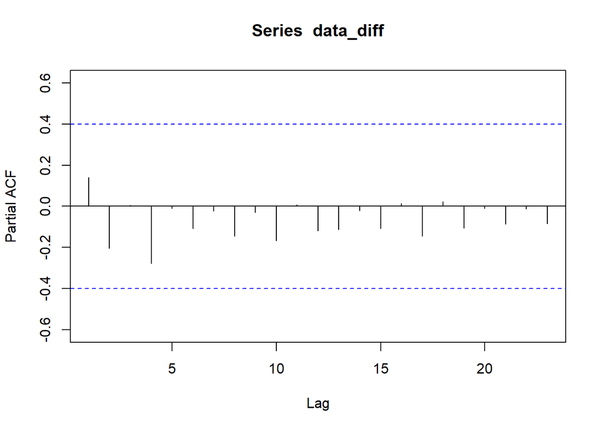

```r
Pacf(data_diff)
```

```r
#Based on the ACF and PACF, which are the possible ARIMA model possible?
```

```r
# Show the AIC, BIC and Sigma^2 for the possible models

fit_arima_mod <- auto.arima(sales_ts,trace=TRUE, stepwise = FALSE )
```

```
##
##  ARIMA(0,0,0)            with zero mean     : 212.8331
##  ARIMA(0,0,0)            with non-zero mean : 114.2918
##  ARIMA(0,0,1)            with zero mean     : Inf
##  ARIMA(0,0,1)            with non-zero mean : 98.17442
##  ARIMA(0,0,2)            with zero mean     : Inf
##  ARIMA(0,0,2)            with non-zero mean : 99.00664
##  ARIMA(0,0,3)            with zero mean     : Inf
##  ARIMA(0,0,3)            with non-zero mean : 99.11057
##  ARIMA(0,0,4)            with zero mean     : Inf
##  ARIMA(0,0,4)            with non-zero mean : 102.2966
##  ARIMA(0,0,5)            with zero mean     : 142.0319
##  ARIMA(0,0,5)            with non-zero mean : 106.2176
##  ARIMA(1,0,0)            with zero mean     : Inf
##  ARIMA(1,0,0)            with non-zero mean : 96.74759
##  ARIMA(1,0,1)            with zero mean     : Inf
##  ARIMA(1,0,1)            with non-zero mean : 97.06879
##  ARIMA(1,0,2)            with zero mean     : Inf
##  ARIMA(1,0,2)            with non-zero mean : 100.0512
##  ARIMA(1,0,3)            with zero mean     : Inf
##  ARIMA(1,0,3)            with non-zero mean : 102.3137
##  ARIMA(1,0,4)            with zero mean     : Inf
##  ARIMA(1,0,4)            with non-zero mean : 106.2174
##  ARIMA(2,0,0)            with zero mean     : Inf
##  ARIMA(2,0,0)            with non-zero mean : 97.39851
##  ARIMA(2,0,1) with zero mean     : Inf
##  ARIMA(2,0,1)            with non-zero mean : 99.52647
##  ARIMA(2,0,2)            with zero mean     : Inf
##  ARIMA(2,0,2)            with non-zero mean : 102.9503
##  ARIMA(2,0,3)            with zero mean     : Inf
##  ARIMA(2,0,3)            with non-zero mean : 106.2187
##  ARIMA(3,0,0)            with zero mean     : Inf
##  ARIMA(3,0,0)            with non-zero mean : 100.5508
##  ARIMA(3,0,1)            with zero mean     : Inf
##  ARIMA(3,0,1)            with non-zero mean : 102.8499
##  ARIMA(3,0,2)            with zero mean     : Inf
##  ARIMA(3,0,2)            with non-zero mean : Inf
##  ARIMA(4,0,0)            with zero mean     : Inf
##  ARIMA(4,0,0)            with non-zero mean : 103.2336
##  ARIMA(4,0,1)            with zero mean     : Inf
##  ARIMA(4,0,1)            with non-zero mean : 106.1298
##  ARIMA(5,0,0)            with zero mean     : Inf
##  ARIMA(5,0,0)            with non-zero mean : 106.8553
##
##
##
##  Best model: ARIMA(1,0,0)            with non-zero mean
```

```r
fit_arima_mod
```

```
## Series: sales_ts
## ARIMA(1,0,0) with non-zero mean
##
## Coefficients:
##          ar1     mean
##       0.7287  16.3164
## s.e.  0.1248   0.9586
##
## sigma^2 = 2.224:  log likelihood = -44.8
## AIC=95.6   AICc=96.75   BIC=99.26
```

# Perform Residual Analysis for this technique.

# Do a plot of residuals. What does the plot indicate?

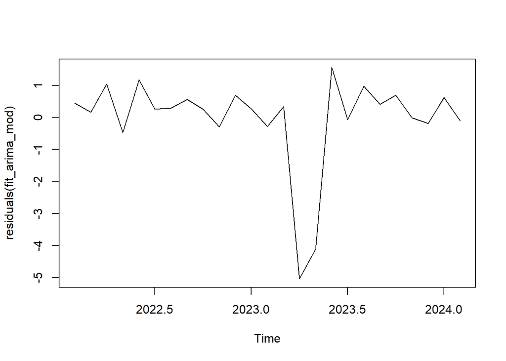

```r
plot.ts(residuals(fit_arima_mod))
```

#The residual plot indicates that most residuals fluctuate around zero, suggesting the ARIMA model captures the trend well. However, the sharp spike in mid-2023 highlights an anomaly that the model struggles to fully account for.

#Do a Histogram plot of residuals. What does the plot indicate?

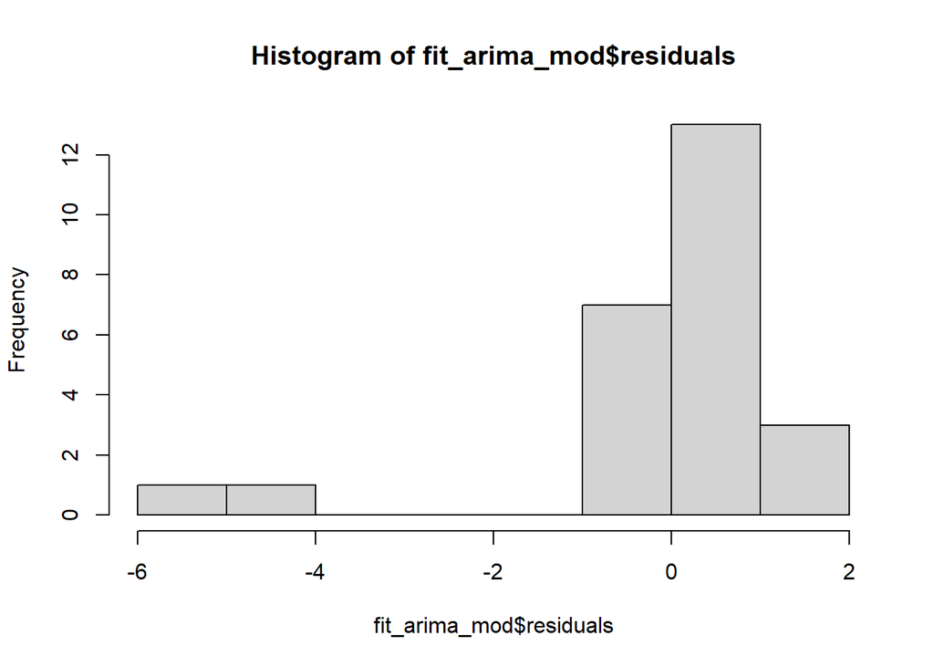

```r
hist(fit_arima_mod$residuals)
```

#Do a plot of actual values vs. residuals. What does the plot indicate?

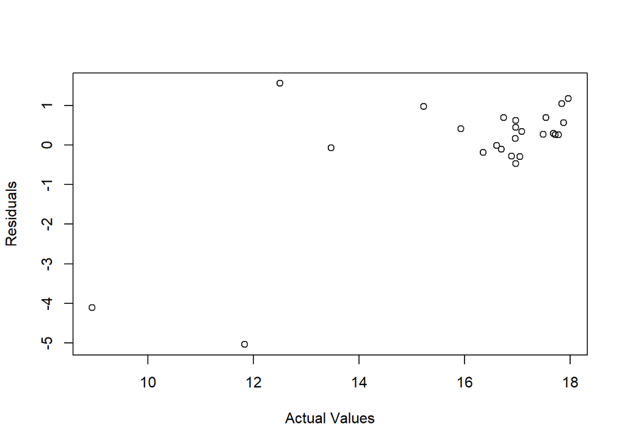

```r
plot(as.numeric(sales_ts), residuals(fit_arima_mod), type='p', ylab='Residuals', xlab='Actual Values')
```

#Do an ACF plot of the residuals? What does this plot indicate?

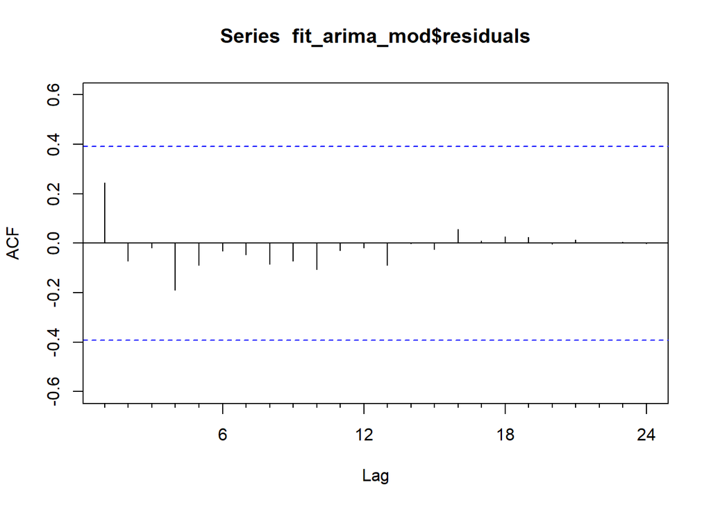

```r
Acf(fit_arima_mod$residuals)
```

#The ACF plot of residuals shows most autocorrelations falling within the confidence bounds, indicating no significant autocorrelation. This suggests that the ARIMA model has adequately captured the underlying structure of the time series.

#No trend or seasonality can be seen in ACF plot.

#Print the 5 measures of accuracy for this forecasting technique.

```r
accuracy(fit_arima_mod)
```

```
##                       ME    RMSE       MAE      MPE     MAPE      MASE
## Training set -0.02729157 1.43048 0.8159089 -1.43548 6.314759 0.3341887
##                   ACF1
## Training set 0.2442309
```

```r
forecast_12 <-forecast(fit_arima_mod, h=12)
```

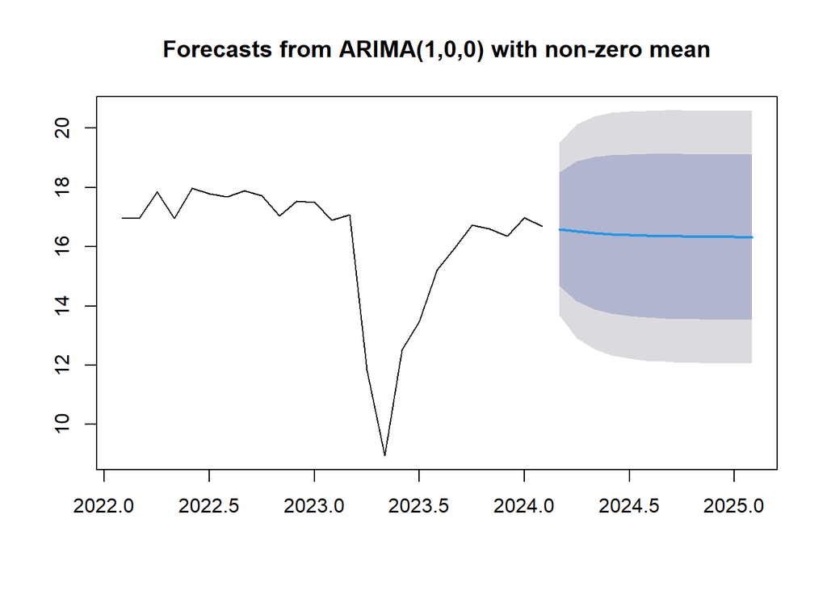

```r
plot(forecast(fit_arima_mod, h=12))
```

#Next two years. Show table and plot

```r
forecast(fit_arima_mod, h=24)
```

```
##          Point Forecast    Lo 80    Hi 80    Lo 95    Hi 95
## Mar 2024       16.59376 14.68249 18.50504 13.67072 19.51681
## Apr 2024       16.51853 14.15358 18.88348 12.90165 20.13541
## May 2024       16.46371 13.89014 19.03727 12.52777 20.39964
## Jun 2024       16.42375 13.74599 19.10151 12.32847 20.51903
## Jul 2024       16.39463 13.66316 19.12611 12.21720 20.57207
## Aug 2024       16.37342 13.61383 19.13300 12.15300 20.59383
## Sep 2024       16.35795 13.58356 19.13235 12.11489 20.60102
## Oct 2024       16.34669 13.56446 19.12891 12.09164 20.60173
## Nov 2024       16.33847 13.55210 19.12485 12.07708 20.59987
## Dec 2024       16.33249 13.54391 19.12107 12.06773 20.59725
## Jan 2025       16.32813 13.53838 19.11787 12.06158 20.59468
## Feb 2025       16.32495 13.53458 19.11532 12.05745 20.59245
## Mar 2025       16.32263 13.53194 19.11333 12.05463 20.59063
## Apr 2025       16.32095 13.53008 19.11182 12.05268 20.58921
## May 2025       16.31972 13.52875 19.11068 12.05131 20.58813
## Jun 2025       16.31882 13.52781 19.10983 12.05033 20.58730
## Jul 2025       16.31817 13.52713 19.10920 12.04964 20.58669
## Aug 2025       16.31769 13.52664 19.10874 12.04914 20.58624
## Sep 2025       16.31734 13.52628 19.10840 12.04879 20.58590
## Oct 2025       16.31709 13.52603 19.10815 12.04853 20.58565
## Nov 2025       16.31691 13.52584 19.10797 12.04834 20.58547
## Dec 2025       16.31677 13.52571 19.10784 12.04820 20.58534
## Jan 2026       16.31667 13.52561 19.10774 12.04810 20.58524
## Feb 2026       16.31660 13.52553 19.10767 12.04803 20.58517
```

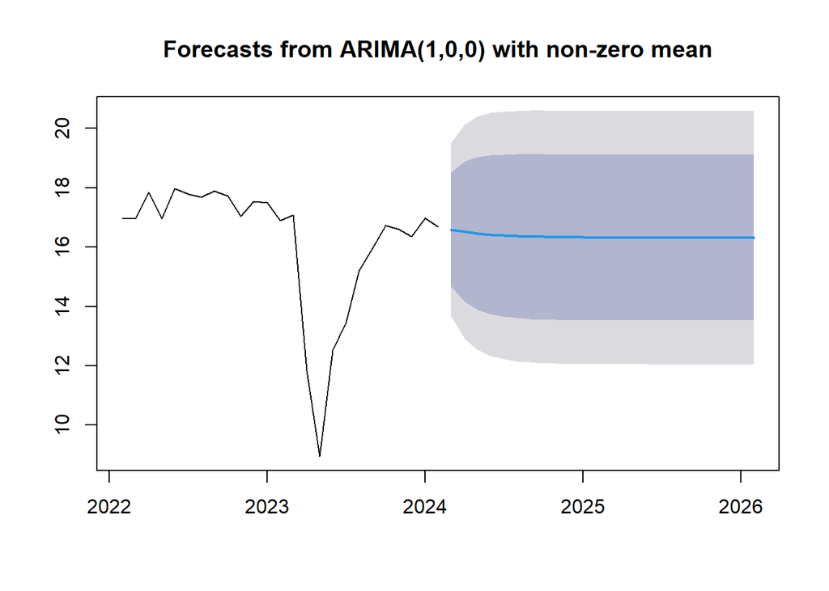

```r
plot(forecast(fit_arima_mod, h=24))
```